# Exercises

## Section 7.2 exercises

1. What function would you use to read a file where fields were separated with “|”?  
   A: with `read_delim(file, "|")`.
2. Apart from `file`, `skip`, and `comment`, what other arguments do `read_csv()` and `read_tsv()` have in common?
3. What are the most important arguments to `read_fwf()`?  
   A: `col_positions` and `col_types`.
4. Sometimes strings in a CSV file contain commas. To prevent them from causing problems, they need to be surrounded by a quoting character, like `"` or `'`. By default, `read_csv()` assumes that the quoting character will be `"`. To read the following text into a data frame, what argument to `read_csv()` do you need to specify?  
   A:

   ```r
   read_csv("x,y\n1,'a,b'", quote = "\'")
   ```

   ```
   ## # A tibble: 1 × 2
   ##       x y
   ##   <dbl> <chr>
   ## 1     1 a,b
   ```

5. Identify what is wrong with each of the following inline CSV files. What happens when you run the code?

   ```r
   read_csv("a,b\n1,2,3\n4,5,6")
   read_csv("a,b,c\n1,2\n1,2,3,4")
   read_csv("a,b\n\"1")
   read_csv("a,b\n1,2\na,b")
   read_csv("a;b\n1;3")
   ```

6. Practice referring to non-syntactic names in the following data frame by:
   1. Extracting the variable called `1`.
   2. Plotting a scatterplot of `1` vs. `2`.
   3. Creating a new column called `3`, which is `2` divided by `1`.
   4. Renaming the columns to `one`, `two`, and `three`.

   ```r
   annoying <- tibble(
     `1` = 1:10,
     `2` = `1` * 2 + rnorm(length(`1`))
   )

   annoying |>
     select(`1`)
   ```

   ```
   ## # A tibble: 10 × 1
   ##      `1`
   ##    <int>
   ##  1     1
   ##  2     2
   ##  3     3
   ##  4     4
   ##  5     5
   ##  6     6
   ##  7     7
   ##  8     8
   ##  9     9
   ## 10    10
   ```

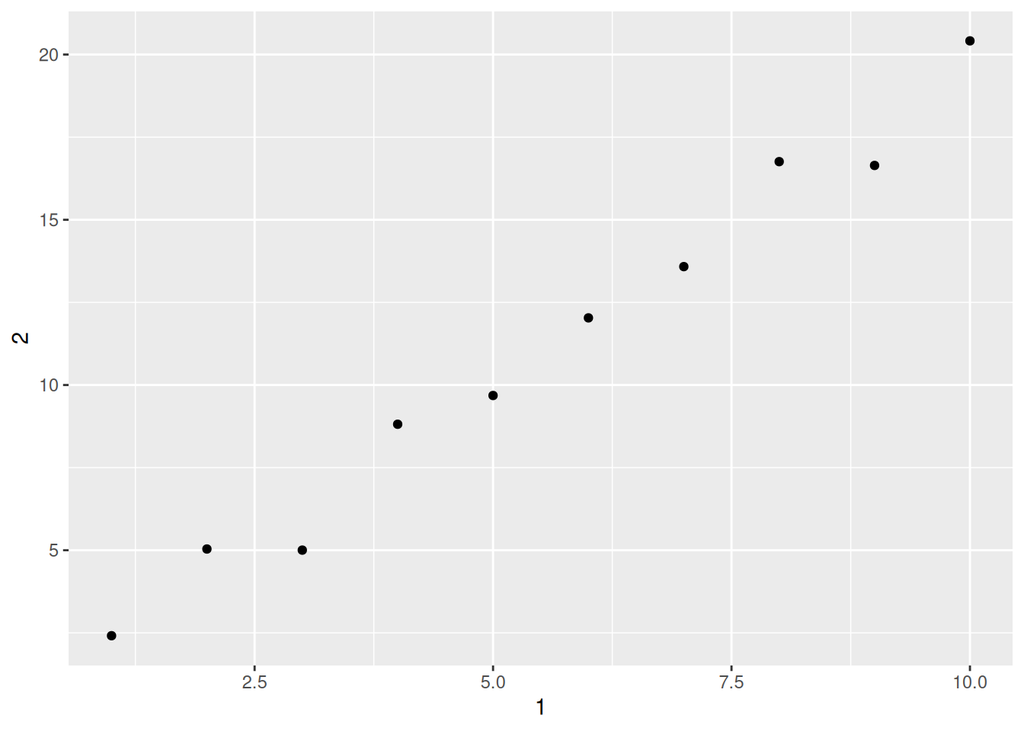

   ```r
   annoying |>
     ggplot(
       aes(x = `1`, y = `2`)
     ) +
     geom_point()
   ```

   ```r
   annoying |>
     mutate(
       `3` = `2` / `1`
     ) |>
     rename(
       one = `1`,
       two = `2`,
       three = `3`
     )
   ```

   ```
   ## # A tibble: 10 × 3
   ##      one   two three
   ##    <int> <dbl> <dbl>
   ##  1     1  2.41  2.41
   ##  2     2  5.04  2.52
   ##  3     3  5.00  1.67
   ##  4     4  8.81  2.20
   ##  5     5  9.68  1.94
   ##  6     6 12.0   2.01
   ##  7     7 13.6   1.94
   ##  8     8 16.8   2.09
   ##  9     9 16.6   1.85
   ## 10    10 20.4   2.04
   ```